# Beliefs and behaviors about COVID-19 in Uganda’s capital

A survey in Kampala, Uganda

## Team

We are a team including experts in the fields of economics, health, and political science. Our team has experience conducting research across sub-Saharan Africa, and over 15 years of research experience in Uganda specifically. The survey is implemented by Innovations for Poverty Action (IPA) Uganda. This survey on COVID-19 builds on an existing project in collaboration with the Kampala Capital City Authority (KCCA). Our team members are listed below:

**PIs:**

- Manuel Bosancianu, research fellow, WZB Berlin Social Science Center
- Ana Garcia-Hernandez, research fellow, WZB Berlin Social Science Center
- Macartan Humphreys, Professor of Political Science, Columbia University and WZB Berlin
- Paul Kiwanuka-Mukiibi, PS Consulting, Uganda
- Melina Platas, Assistant Professor of Political Science, NYU Abu Dhabi
- Leah Rosenzweig, Postdoctoral Fellow, Stanford University
- Lily Tsai, Ford Professor of Political Science, Massachusetts Institute of Technology

**Research staff:**

- Anthony Kamwesigye, Innovations for Poverty Action
- Diana Zhu, PhD Student, Massachusetts Institute of Technology
- Elly Atuhumuza, Innovations for Poverty Action
- Julian Cantor, WZB Berlin Social Science Center
- Julio Solís, WZB Berlin Social Science Center
- Martin Atyera, Innovations for Poverty Action
- Rodrigo Cordova Ponce, Massachusetts Institute of Technology
- Sisi Huang, WZB Berlin Social Science Center

**Survey team:**

- Adede Deborah
- Amanya Joshua
- Amara Andrew
- Atukwatse Naome
- Bakashaba Kenneth
- Esther K
- Grace Nabitaka
- Kabarungi Sophie
- Kembabazi Allen
- Louis Joseph
- Mayanja Patrick
- Mukunzi Ivan
- Musa Muzei
- Naigaga Sophia
- Naluwooza Flavia Byaruhanga
- Namagembe Angella
- Namboowa Betty
- Namuganga Sylvia
- Ssenyonjo Julius

## How To

To download data or search for an indicator, select the “All data” tab. Data can be downloaded as a csv or Excel file.

For comments or questions on the dashboard, please email Julio Solís at julio.solis@wzb.eu.

## Aid

### Aggregates

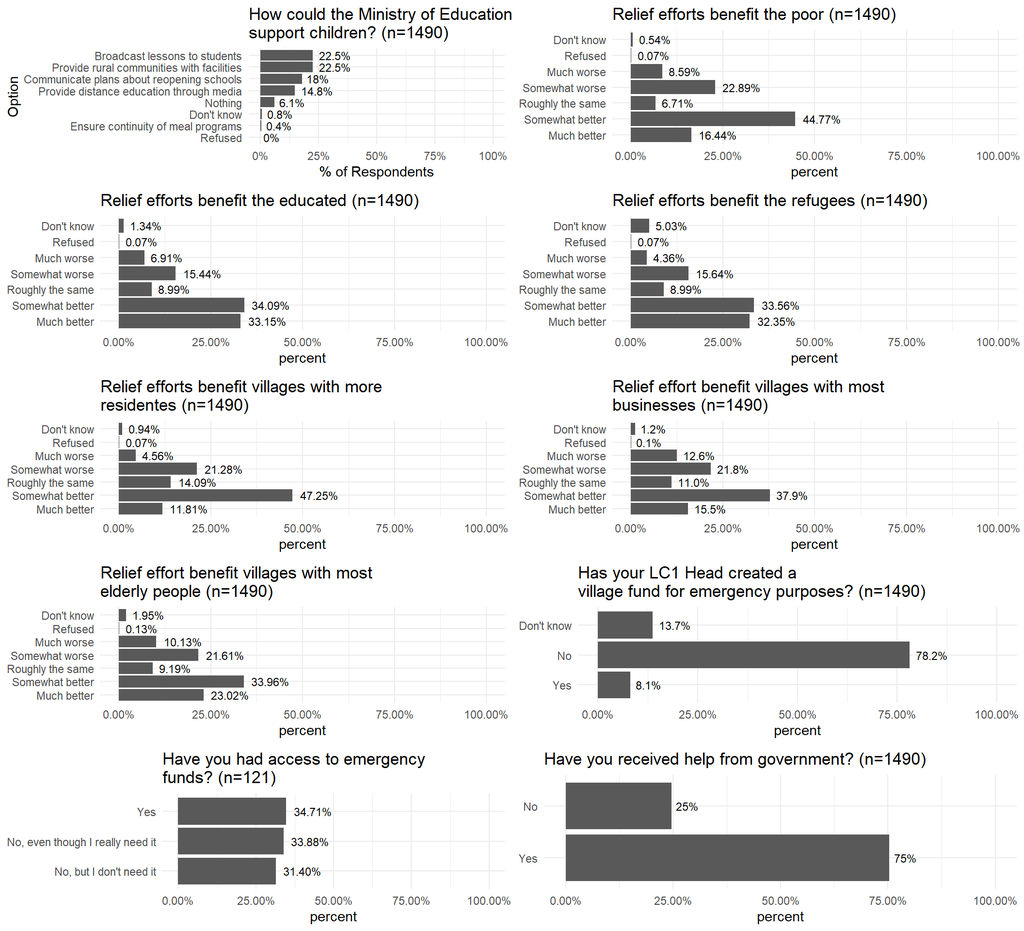

### Definitions of measures

Data definitions

| Measure | Definition |
| --- | --- |
| Relief efforts benefit the poor | Generally do you think the following types of villages do especially well or especially badly relative to other villages? “Villages with many poor people” |
| Relief efforts benefit the educated | Generally do you think the following types of villages do especially well or especially badly relative to other villages? “Villages with many educated people” |
| Relief efforts benefit the refugees | Generally do you think the following types of villages do especially well or especially badly relative to other villages? “Villages with many refugees” |
| Relief efforts benefit villages with more residentes | Generally do you think the following types of villages do especially well or especially badly relative to other villages? “Villages with more residents” |
| Relief effort benefit villages with most businesses | Generally do you think the following types of villages do especially well or especially badly relative to other villages? “Villages that have more businesses in them” |
| Relief effort benefit villages with most elderly people | Generally do you think the following types of villages do especially well or especially badly relative to other villages? “Villages with more elderly people” |
| Has your LC1 Head created a village fund for emergency purposes? | Has your LC1 Head created a village fund for emergency purposes? |
| Have you had access to emergency funds? | Have you had access to any of the funds? |
| Have you received help from government? | Since the beginning of the pandemic, have you or your household received any help from the government and/or other sources? |
| Provide distance education through media | What do you think the Ministry of Education could do to support children the most in this period? Provide distance education programs through the media |
| Provide rural communities with facilities | What do you think the Ministry of Education could do to support children the most in this period? Provide rural communities with facilities to particiate in the distance educatio |
| Broadcast lessons to students | What do you think the Ministry of Education could do to support children the most in this period? Launching TV/radio channels to broadcast lessons to students |
| Communicate plans about reopening schools | What do you think the Ministry of Education could do to support children the most in this period? Communicate to parents about government’s plans about reopening schools |
| Ensure continuity of meal programs | What do you think the Ministry of Education could do to support children the most in this period? Ensure continuity of meal programs to students in school feeding programs |
| Nothing | What do you think the Ministry of Education could do to support children the most in this period? Nothing |
| Don’t know | What do you think the Ministry of Education could do to support children the most in this period? Don’t know |
| Refused | What do you think the Ministry of Education could do to support children the most in this period? Refused |

## Daily behavior

### Aggregates

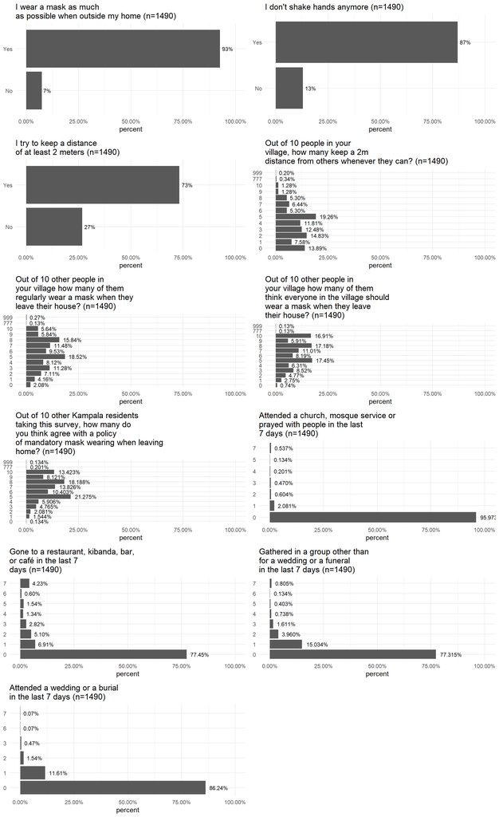

### Definitions of measures

Data definitions

| Measure | Definition |
| --- | --- |
| I wear a mask as much as possible when outside my home | Which of the following is true for you?: I wear a mask as much as possible when outside my home |
| I don’t shake hands anymore | Which of the following is true for you?: I don’t shake hands anymore |
| I try to keep a distance of at least 2 meters | Which of the following is true for you?: I try to keep a distance of at least 2 meters from people outside my household |
| Out of 10 people in your village, how many keep a 2m distance from others whenever they can? | Out of 10 people in your village, how many keep a 2m distance from others whenever they can? |
| Out of 10 other people in your village how many of them regularly wear a mask when they leave their house? | Out of 10 other people in your village how many of them regularly wear a mask when they leave their house? |
| Out of 10 other people in your village how many of them think everyone in the village should wear a mask when they leave their house? | Out of 10 other people in your village how many of them think everyone in the village should wear a mask when they leave their house? |
| Out of 10 other Kampala residents taking this survey, how many do you think agree with a policy of mandatory mask wearing when leaving home? | Out of 10 other Kampala residents taking this survey, how many do you think agree with a policy of mandatory mask wearing when leaving home? |
| Attended a church, mosque service or prayed with people in the last 7 days | In the past 7 days, about how many days have you . . . . Attended a church or mosque service, or gathered with people from outside your household to pray? |
| Gone to a restaurant, kibanda, bar, or café in the last 7 days | In the past 7 days, about how many days have you. . . . Gone to a restaurant, kibanda, bar, or café? |
| Gathered in a group other than for a wedding or a funeral in the last 7 days | In the past 7 days, about how many days have you. . . . Gathered in a group of more than 5 people other than for a wedding or a funeral? |
| Attended a wedding or a burial in the last 7 days | In the past 7 days, about how many days have you. . . . Attended a wedding or a burial with more than 10 people? |

## Economic impact

### Aggregates

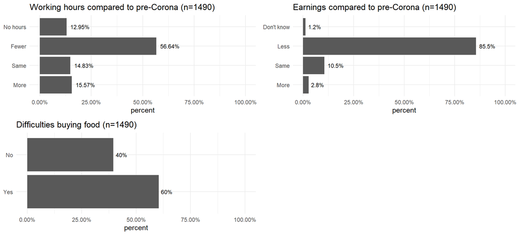

### Definitions of measures

Data definitions

| Measure | Definition |
| --- | --- |
| Working hours compared to pre-Corona | In the past 7 days, did you spend more, the same, fewer or no hours (working for pay/ running a business/ helping on a family business) than you did in a typical week before government closed the scho… |
| Earnings compared to pre-Corona | During the past 7 days, did you earn more, the same, or less pay than you did in a typical week before government closed the schools? |
| Difficulties buying food | In the past 7 days, have you or any household member experienced difficulties in buying food? |

## Government performance

### Aggregates

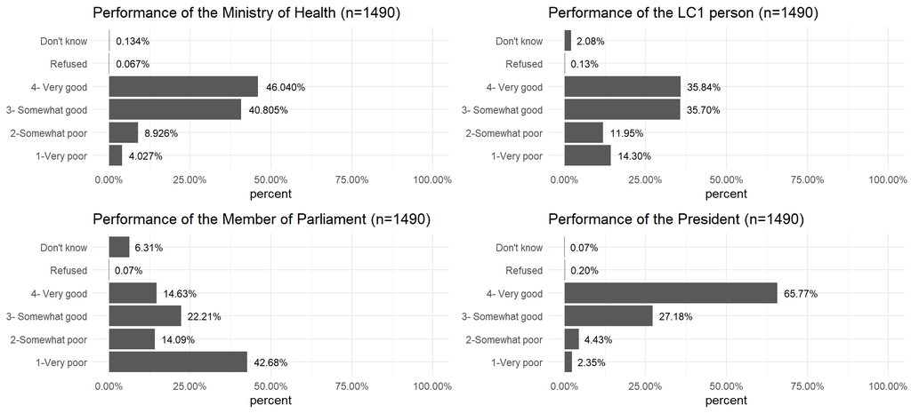

### Definitions of measures

Data definitions

| Measure | Definition |
| --- | --- |
| Performance of the Ministry of Health | How would you rate the performance of Ministry of Health in handling COVID in Uganda? |
| Performance of the LC1 person | How would you rate the performance of your LC1 chairperson in handling COVID in Uganda? |
| Performance of the Member of Parliament | How would you rate the performance of the MP for your area in handling COVID in Uganda? |
| Performance of the President | How would you rate the performance of each of the following in handling COVID in Uganda? The president |

## Health

### Aggregates

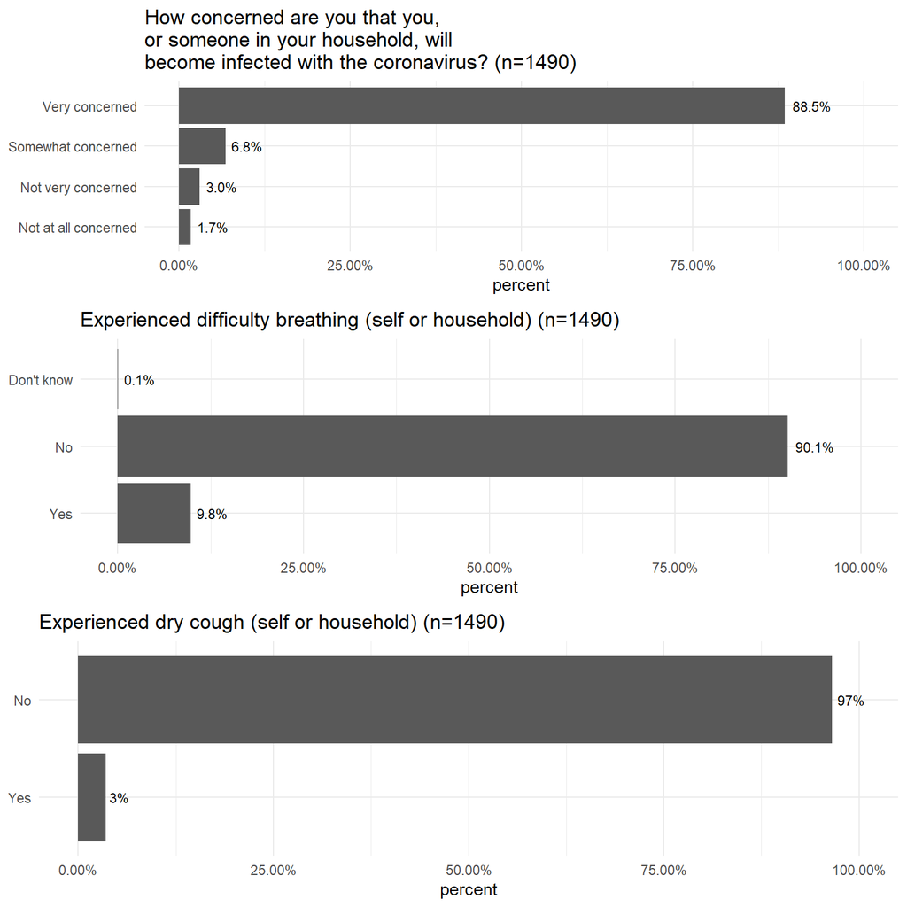

### Definitions of measures

Data definitions

[output not shown]

## Mask behavior and perception

### Aggregates

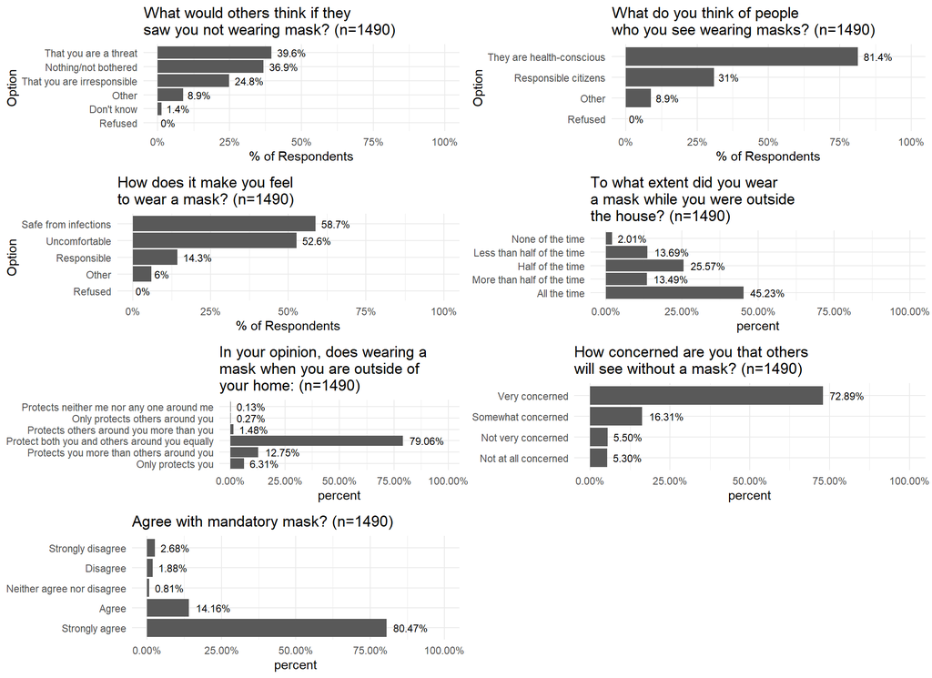

### Definitions of measures

Data definitions

| Measure | Definition |
| --- | --- |
| To what extent did you wear a mask while you were outside the house? | Understanding that some people are not able to wear masks all the time, the last time you left home, to what extent did you wear a mask that fully covered your nose and mouth while you were outside th… |
| In your opinion, does wearing a mask when you are outside of your home: | In your opinion, does wearing a mask when you are outside of your home: |
| How concerned are you that others will see without a mask? | To what exent are you concerned or unconcerned if other people in your village see you outside your home without wearing a mask? |
| Agree with mandatory mask? | To what extent do you agree or disagree with a policy of mandatory mask wearing when leaving home? |
| Nothing/not bothered | What would other people in your village think of you if they saw you not wearing your mask? Nothing/not bothered since some also don’t wear masks |
| That you are a threat | What would other people in your village think of you if they saw you not wearing your mask? That you are a threat to the community |
| That you are irresponsible | What would other people in your village think of you if they saw you not wearing your mask? That you are irresponsible |
| Other | What would other people in your village think of you if they saw you not wearing your mask? Other |
| Don’t know | What would other people in your village think of you if they saw you not wearing your mask? Don’t know |
| Refused | What would other people in your village think of you if they saw you not wearing your mask? Refused |
| Responsible citizens | When you see people wearing masks, what do you think of them? Responsible citizens |
| They are health-conscious | When you see people wearing masks, what do you think of them? They are health conscious |
| Other | When you see people wearing masks, what do you think of them? Other |
| Refused | When you see people wearing masks, what do you think of them? Refused |
| Uncomfortable | How does it make you feel to wear a mask? Uncomfortable |
| Responsible | How does it make you feel to wear a mask? Responsible |
| Safe from infections | How does it make you feel to wear a mask? Safe from infections |
| Other | How does it make you feel to wear a mask? Other |
| Refused | How does it make you feel to wear a mask? Refused |

## Trust

### Aggregates

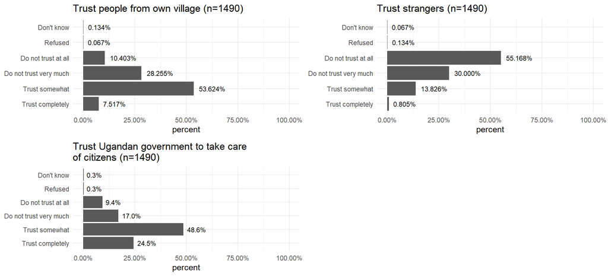

### Definitions of measures

Data definitions

| Measure | Definition |
| --- | --- |
| Trust people from own village | Now I want to ask you how much you generally trust different types of people. How much do you generally trust. … People from your village? |
| Trust strangers | How much do you generally trust. … People you meet for the first time (strangers)? |
| Trust Ugandan government to take care of citizens | How much do you generally trust the Ugandan government to take care of its citizens? |

## All Data

### Browse data

|  | id | date | gvtaid_poor | gvtaid_educated | gvtaid_refugees | gvtaid_moresidents | gvtaid_mobuss | gvtaid_elderly | vill_fund | access_funds | receive_aid | wear_mask | not_shakehand | social_dist | follow_sociodist | mask_regular | mask_wearing | mand_other | gathered | cafe | comm_meet | social_gather | spend_hrs | earnings | mob_restr | per_moh | per_lc1 | per_mp | per_president | … |
| --- | --- | --- | --- | --- | --- | --- | --- | --- | --- | --- | --- | --- | --- | --- | --- | --- | --- | --- | --- | --- | --- | --- | --- | --- | --- | --- | --- | --- | --- | --- |
| 1 | 1031-10 | 2020-09-04 | Much worse | Somewhat better | Much worse | Somewhat better | Somewhat better | Much worse | No |  | Yes | Yes | Yes | No | 3 | 8 | 7 | 6 | 0 | 0 | 2 | 0 | Fewer | Less | Yes | 4- Very good | 3- Somewhat good | Don't know | 4- Very good | … |
| 2 | 1022-11 | 2020-09-04 | Somewhat better | Somewhat better | Somewhat better | Somewhat worse | Roughly the same | Somewhat better | No |  | No | Yes | Yes | Yes | 2 | 2 | 3 | 3 | 0 | 0 | 0 | 1 | Fewer | Less | Yes | 1-Very poor | 3- Somewhat good | 1-Very poor | 3- Somewhat good | … |
| 3 | 1001-11 | 2020-09-04 | Much better | Somewhat better | Much better | Much better | Somewhat better | Much better | No |  | Yes | Yes | Yes | Yes | 3 | 2 | 8 | 9 | 0 | 0 | 2 | 0 | Fewer | Less | Yes | 4- Very good | 3- Somewhat good | 1-Very poor | 4- Very good | … |
| 4 | 1067-10 | 2020-09-04 | Somewhat better | Much better | Somewhat better | Somewhat better | Somewhat better | Somewhat better | No |  | Yes | Yes | Yes | No | 0 | 6 | 9 | 9 | 0 | 0 | 1 | 1 | More | Less | No | 4- Very good | 1-Very poor | 1-Very poor | 4- Very good | … |
| 5 | 1026-09 | 2020-09-04 | Somewhat better | Much better | Somewhat better | Somewhat better | Much better | Much better | Don't know |  | Yes | Yes | Yes | Yes | 2 | 5 | 5 | 10 | 0 | 0 | 1 | 1 | Fewer | Less | Yes | 4- Very good | 4- Very good | Don't know | 4- Very good | … |
| 6 | 1004-10 | 2020-09-04 | Much better | Somewhat worse | Somewhat better | Somewhat better | Much worse | Much better | No |  | Yes | Yes | Yes | Yes | 3 | 4 | 2 | 6 | 0 | 0 | 1 | 1 | Fewer | Less | Yes | 2-Somewhat poor | 2-Somewhat poor | 1-Very poor | 4- Very good | … |
| 7 | 1002-09 | 2020-09-04 | Somewhat better | Roughly the same | Somewhat worse | Somewhat worse | Somewhat better | Somewhat better | Don't know |  | Yes | Yes | Yes | Yes | 5 | 5 | 7 | 5 | 0 | 3 | 2 | 0 | More | Same | Yes | 3- Somewhat good | 4- Very good | 2-Somewhat poor | 4- Very good | … |
| 8 | 1134-10 | 2020-09-04 | Much worse | Much better | Much worse | Much better | Much better | Somewhat better | No |  | Yes | Yes | Yes | Yes | 2 | 1 | 3 | 4 | 1 | 0 | 1 | 1 | More | Less | Yes | 3- Somewhat good | 3- Somewhat good | 1-Very poor | 3- Somewhat good | … |
| 9 | 1091-11 | 2020-09-04 | Much better | Much worse | Much better | Much better | Much worse | Much better | No |  | Yes | Yes | Yes | Yes | 3 | 8 | 10 | 10 | 0 | 0 | 0 | 0 | Fewer | Less | No | 4- Very good | 2-Somewhat poor | 1-Very poor | 4- Very good | … |
| 10 | 1009-10 | 2020-09-04 | Somewhat worse | Much better | Somewhat better | Somewhat worse | Somewhat worse | Somewhat better | Yes | No, even though I really need it | Yes | Yes | Yes | No | 0 | 8 | 7 | 9 | 0 | 1 | 1 | 0 | Same | Same | Yes | 3- Somewhat good | 3- Somewhat good | 3- Somewhat good | 4- Very good | … |

[output cut: 1480 more lines]

### Data summaries

**Technical**: Summary measures on all data.

[output not shown]

[output cut: 21 more lines]

Notes